# Second Degree Equations Part 1

Luke Bordonaro

## Topics

- Understanding the degree of an equation
- How to use the *quadratic formula*
- How to factor any second degree expression with the *quadratic formula*
- How to graph a parabola
- How to solve a 2nd degree word problem by
  - Graphing
  - Factoring directly
  - Using the quadratic equation

## Some Review on Polynomials

- Recall that a polynomial is a collection of terms. For example, $x^4 + 2x^2 + 5$ is a polynomial.
- The *degree* of a polynomial is the highest exponent it has.
  - $x^4 + 2x^2 + 5$ is a *fourth*, $4^{\text{th}}$, degree polynomial, because the highest exponent is $4$
- A *second degree equation* is an equation where the maximum degree on either side is $2$
  - $x^2 + 2x + 3 = 0$ is an example of a second degree equation

## Practice

For each of the following equations, determine if it is a second degree equation

\begin{gather} x^3 + 2x^2 + 5x - = 0 \\ x^2 - 10x + 2 = 0 \\ x - 105 = 0 \\ x^2 = 25 \\ x^2 + 2x = 0 \\ 0x^3 + 2x^2 + 8x - 5 = 2 \end{gather}

## Practice

For each of the following equations, determine if it is a second degree equation

\begin{gather} x^3 + 2x^2 + 5x - = 0 & \text{NO}\\ x^2 - 10x + 2 = 0 \\ x - 105 = 0 \\ x^2 = 25 \\ x^2 + 2x = 0 \\ 0x^3 + 2x^2 + 8x - 5 = 2 \end{gather}

## Practice

For each of the following equations, determine if it is a second degree equation

\begin{gather} x^3 + 2x^2 + 5x - = 0 & \text{NO}\\ x^2 - 10x + 2 = 0 & \text{YES}\\ x - 105 = 0 \\ x^2 = 25 \\ x^2 + 2x = 0 \\ 0x^3 + 2x^2 + 8x - 5 = 2 \end{gather}

## Practice

For each of the following equations, determine if it is a second degree equation

\begin{gather} x^3 + 2x^2 + 5x - = 0 & \text{NO}\\ x^2 - 10x + 2 = 0 & \text{YES}\\ x - 105 = 0 & \text{NO}\\ x^2 = 25 \\ x^2 + 2x = 0 \\ 0x^3 + 2x^2 + 8x - 5 = 2 \end{gather}

## Practice

For each of the following equations, determine if it is a second degree equation

\begin{gather} x^3 + 2x^2 + 5x - = 0 & \text{NO}\\ x^2 - 10x + 2 = 0 & \text{YES}\\ x - 105 = 0 & \text{NO}\\ x^2 = 25 & \text{YES}\\ x^2 + 2x = 0 \\ 0x^3 + 2x^2 + 8x - 5 = 2 \end{gather}

## Practice

For each of the following equations, determine if it is a second degree equation

\begin{gather} x^3 + 2x^2 + 5x - = 0 & \text{NO}\\ x^2 - 10x + 2 = 0 & \text{YES}\\ x - 105 = 0 & \text{NO}\\ x^2 = 25 & \text{YES}\\ x^2 + 2x = 0 & \text{YES}\\ 0x^3 + 2x^2 + 8x - 5 = 2 \end{gather}

## Practice

For each of the following equations, determine if it is a second degree equation

\begin{gather} x^3 + 2x^2 + 5x - = 0 & \text{NO}\\ x^2 - 10x + 2 = 0 & \text{YES}\\ x - 105 = 0 & \text{NO}\\ x^2 = 25 & \text{YES}\\ x^2 + 2x = 0 & \text{YES}\\ 0x^3 + 2x^2 + 8x - 5 = 2 & \text{YES} \end{gather}

## Solving Second Degree (Quadratic) Equations

We are going to be interested in solving the equation

\begin{equation} ax^2 + bx + c = 0 \end{equation}

Why $=0$?

Suppose we have a problem involving any quadratic equation. For example, the forms

\begin{align} x^2 &= bx + c \\ x^2 + bc &= c \end{align}

where we are trying to solve for $x$. We can always re-arrange terms to set it equal to $0$

\begin{align} x^2 = bx + c \ &\rightarrow \ x^2 - bx - c = 0 \\ x^2 + bc = c \ &\rightarrow \ x^2 + bx - c = 0 \end{align}

Solving these equations gives the answers $x$ that solve the original equations!

## Graphically solve the equation

Let's say we are trying to solve $x^2 - 4 = 0$. Here is what the graph of $x^2 - 4$ looks like (we will learn how to graph later)

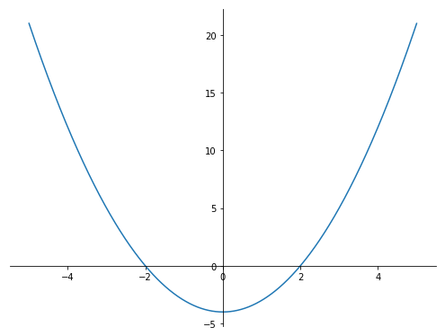

```python
#hideme
x = np.arange(-5, 5, 0.001)
y = x**2 - 4

fig = plt.figure(figsize=(8.5, 6.5))
ax = fig.add_subplot(111)
ax.plot(x, y)
ax.spines['left'].set_position('zero')
ax.spines['right'].set_color('none')
ax.spines['bottom'].set_position('zero')
ax.spines['top'].set_color('none')
ax.xaxis.set_ticks_position('bottom')
ax.yaxis.set_ticks_position('left')
```

The shape of this graph is called a *parabola*. **All second degree equations have the same shape.** What do we notice about the solution to $x^2 - 4 = 0$?

## Introducing: the *Quadratic Formula* (the Quadratic Equation)

Given an equation of the form

\begin{equation} ax^2 + bx + c = 0 \end{equation}

we can calculate the values of $x$ that solve the equation with

\begin{equation} x = \frac{-b \pm \sqrt{b^2 - 4ac}}{2a} \end{equation}

Notice the $\pm$ here. This gives us two values, as we expect!

These values of $x$ are called the *roots of the parabola*.

## *Quadratic Formula* Example

Let's try it out on our previous example $x^2 - 4 = 0$. Here we have $a = 1$, $b = 0$, $c = -4$.

\begin{align} x &= \frac{-b \pm \sqrt{b^2 - 4ac}}{2a} \\ x &= \frac{0 \pm \sqrt{0 - 4\cdot 1\cdot (-4)}}{2\cdot 1} \\ x &= \frac{\pm \sqrt{16}}{2} \\ x &= \frac{\pm 4}{2} \\ x &= \pm 2 \end{align}

We get $x=2$, $x=-2$, like we expected!

## Let's practice!

In groups of three, solve each of the following equations for $x$ using the quadratic formula

\begin{align} x^2 - 1 &= 0 \\ x^2 - 3x - 10 &= 0 \\ x^2 + 4x - 5 &= 0 \\ x^2 + 1 &= 1 \\ -x^2 + x + 4 &= -2 \end{align}

## Let's practice example 1

\begin{equation} x^2 - 1 = 0 \end{equation}

$a=1$, $b=0$, $c=-1$

\begin{align} x &= \frac{-b \pm \sqrt{b^2 - 4ac}}{2a} \\ x &= \frac{0 \pm \sqrt{0 - 4\cdot 1 \cdot (-1)}}{2\cdot 1} \\ x &= \frac{\pm\sqrt{4}}{2} \\ x &= \frac{\pm 2}{2} \\ x &= 1, -1 \end{align}

## Let's practice example 2

\begin{equation} x^2 - 3x -10 = 0 \end{equation}

$a=1$, $b=-3$, $c=-10$

\begin{align} x &= \frac{-b \pm \sqrt{b^2 - 4ac}}{2a} \\ x &= \frac{3 \pm \sqrt{9 - 4\cdot 1 \cdot (-10)}}{2\cdot 1} \\ x &= \frac{3 \pm\sqrt{9 + 40}}{2} \\ x &= \frac{3 \pm 7}{2} \\ x &= 5, -2 \end{align}

## Let's practice example 3

\begin{equation} x^2 +4x -5 = 0 \end{equation}

$a=1$, $b=4$, $c=-5$

\begin{align} x &= \frac{-b \pm \sqrt{b^2 - 4ac}}{2a} \\ x &= \frac{-4 \pm \sqrt{16 - 4\cdot 1 \cdot (-5)}}{2\cdot 1} \\ x &= \frac{-4 \pm\sqrt{16 + 20}}{2} \\ x &= \frac{-4 \pm 6}{2} \\ x &= 1, -5 \end{align}

## Let's practice example 4

\begin{align} x^2 + 1 = 1 \\ x^2 = 0 \end{align}

$a=1$, $b=0$, $c=0$

\begin{align} x &= \frac{-b \pm \sqrt{b^2 - 4ac}}{2a} \\ x &= \frac{0 \pm \sqrt{0 - 4\cdot 1 \cdot 0}}{2\cdot 1} \\ x &= \frac{0 \pm\sqrt{0 + 0}}{2} \\ x &= \frac{0 \pm\sqrt{0}}{2} \\ x &= 0, 0 \end{align}

## Let's practice example 5

\begin{align} -x^2 + x + 4 = -2 \ \rightarrow \ -x^2 + x + 6 = 0 \end{align}

$a=-1$, $b=1$, $c=6$

\begin{align} x &= \frac{-b \pm \sqrt{b^2 - 4ac}}{2a} \\ x &= \frac{-1 \pm \sqrt{1 - 4\cdot -1 \cdot 6}}{2\cdot -1} \\ x &= \frac{-1 \pm\sqrt{1 + 24}}{-2} \\ x &= \frac{-1 \pm 5}{-2} \\ x &= -2, 3 \end{align}

## The Discriminant

$$b^2 - 4ac$$

is a *very* important number in our calculation (why?). It is called *the discriminant*.

- If $b^2 - 4ac > 0$ then we have two *real roots* (two solutions)
- If $b^2 - 4ac = 0$ then we have *repeated roots* (one solution)
- If $b^2 - 4ac < 0$ then roots our roots are not real (not real solutions)

## True or False: Roots are always rational numbers

False. If the discriminant is not a perfect square (i.e. $4$, $9$, $16$...) then $\sqrt{b^2 - 4ac}$ will be *irrational*. This means are roots themselves are also irrational.

## Let's practice!

In groups of three, determine if the roots of each parabola are real, complex, or repeated. If they are real, determine if they are rational or irrational.

\begin{align} x^2 - 5x +4 &= 0 \\ x^2 - 3x + 1 &= 0 \\ x^2 + 4x + 4 &= 0 \end{align}

## Let's practice!

In groups of three, determine if the roots of each parabola are real, complex, or repeated. If they are real, determine if they are rational or irrational.

\begin{align} x^2 - 5x + 4 &= 0 && b^2 - 4ac = 25 - 16 = 9 \rightarrow \text{ real, rational}\\ x^2 - 3x + 1 &= 0 \\ x^2 + 4x + 4 &= 0 \\ x^2 + x + 10 &= 0 \end{align}

## Let's practice!

In groups of three, determine if the roots of each parabola are real, complex, or repeated. If they are real, determine if they are rational or irrational.

\begin{align} x^2 - 5x + 4 &= 0 && b^2 - 4ac = 25 - 16 = 9 \rightarrow \text{ real, rational}\\ x^2 - 3x + 1 &= 0 && b^2 - 4ac = 9 - 4 = 5 \rightarrow \text{ real, irrational}\\ x^2 + 4x + 4 &= 0 \\ x^2 + x + 10 &= 0 \end{align}

## Let's practice!

In groups of three, determine if the roots of each parabola are real, complex, or repeated. If they are real, determine if they are rational or irrational.

\begin{align} x^2 - 5x + 4 &= 0 && b^2 - 4ac = 25 - 16 = 9 \rightarrow \text{ real, rational}\\ x^2 - 3x + 1 &= 0 && b^2 - 4ac = 9 - 4 = 5 \rightarrow \text{ real, irrational}\\ x^2 + 4x + 4 &= 0 && b^2 - 4ac = 16 - 16 = 0 \rightarrow \text{ repeated} \\ x^2 + x + 10 &= 0 \end{align}

## Let's practice!

In groups of three, determine if the roots of each parabola are real, complex, or repeated. If they are real, determine if they are rational or irrational.

\begin{align} x^2 - 5x + 4 &= 0 && b^2 - 4ac = 25 - 16 = 9 \rightarrow \text{ real, rational}\\ x^2 - 3x + 1 &= 0 && b^2 - 4ac = 9 - 4 = 5 \rightarrow \text{ real, irrational}\\ x^2 + 4x + 4 &= 0 && b^2 - 4ac = 16 - 16 = 0 \rightarrow \text{ repeated} \\ x^2 + x + 10 &= 0 && b^2 - 4ac = 1 - 40 = -39 \rightarrow \text{ complex} \\ \end{align}

## Tomorrow

Tomorrow we will see how we can use the quadratic formula to factor *any* quadratic expression.